# **Lab 7: Sequential Networks**

**Name(s):** Emmanuel Garcia, Nimai Keshu, Tiffany Nguyen, Luke Voinov

We use the Grammar Error Correction Dataset:

https://www.kaggle.com/datasets/programmer3/grammar-error-correction-dataset

Much of the code in this dataset was adapted from Eric Larson, 13a. Sequence Basics [experimental].ipynb

https://github.com/eclarson/MachineLearningNotebooks/blob/master/13a.%20Sequence%20Basics%20%5Bexperimental%5D.ipynb

We denote this reference with (1)

```python
# Import any dependencies

import pandas as pd
import numpy as np
from sklearn.model_selection import train_test_split, StratifiedKFold
import matplotlib.pyplot as plt
from sklearn.preprocessing import LabelEncoder

print('Pandas:', pd.__version__)
print('Numpy:',np.__version__)
# Python: 3.12.3
```

```
Pandas: 2.2.2
Numpy: 2.0.2
```

# **1 Preparation**

1.1 *Define and prepare your class variables. Use proper variable representations (int, float, one-hot, etc.). Use pre-processing methods (as needed) for dimensionality reduction, scaling, etc. Remove variables that are not needed/useful for the analysis. Describe the final dataset that is used (include a description of any newly formed variables you created). It is preferred to use tf.dataset and Keras Feature spaces for pre-processing, but it is not required.*

```python
# read the items.csv (book information) into df1
path = "grammar_error_dataset.csv"
df = pd.read_csv(path, encoding='utf-8')
```

```python
df.head()
```

|  | ID | Learner_Proficiency | Topic | Original_Sentence | Error_Type | Corrected_Sentence | Grammar_Rule | POS_Tagged | Tokenized | Error_Position |
| --- | --- | --- | --- | --- | --- | --- | --- | --- | --- | --- |
| 0 | 1 | Advanced | Health | He bought two breads. | Noun Form | He bought two loaves of bread. | Use correct plural form or measure word. | He/PRP bought/VBD two/CD breads/NNS ./. | He bought two breads . | 1 |
| 1 | 2 | Advanced | Health | She go to market yesterday. | Verb Tense | She went to the market yesterday. | Use past tense for actions completed in the past. | She/PRP go/VBP to/TO market/NN yesterday/NN ./. | She go to market yesterday . | 0 |
| 2 | 3 | Advanced | Sports | Always I drink coffee in morning. | Word Order | I always drink coffee in the morning. | Adverbs of frequency go before the main verb. | Always/NNS I/PRP drink/VBP coffee/NN in/IN mor... | Always I drink coffee in morning . | 1 |
| 3 | 4 | Beginner | Sports | Always I drink coffee in morning. | Word Order | I always drink coffee in the morning. | Adverbs of frequency go before the main verb. | Always/NNS I/PRP drink/VBP coffee/NN in/IN mor... | Always I drink coffee in morning . | 2 |
| 4 | 5 | Beginner | Technology | He is married with a doctor. | Preposition | He is married to a doctor. | ‘Married to’ is the correct collocation. | He/PRP is/VBZ married/VBN with/IN a/DT doctor/... | He is married with a doctor . | 4 |

```python
print(f"\nItems shape: {df.shape}")
print(f"Items dtypes:\n{df.dtypes}")
```

```
Items shape: (1750, 10)
Items dtypes:
ID                      int64
Learner_Proficiency    object
Topic                  object
Original_Sentence      object
Error_Type             object
Corrected_Sentence     object
Grammar_Rule           object
POS_Tagged             object
Tokenized              object
Error_Position          int64
dtype: object
```

#### Data Cleaning

First, we see if any data is missing. Next, we'll remove, combine, or create columns.

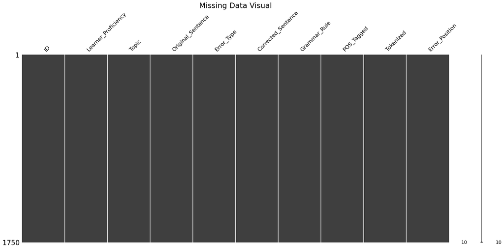

```python
# Code adapted from voinov_lab1.ipynb

import warnings
warnings.simplefilter('ignore', DeprecationWarning)
%matplotlib inline

# External package: conda install missingno
import missingno as mn

mn.matrix(df)
plt.title("Missing Data Visual",fontsize=22)
```

We remove the ID, Corrected_Sentence, POS_Tagged, Tokenized, and Error_Position columns.

The ID column won't contribue any meaningful information about the grammar. It's an artifact of organizing the data and has no realtion to a person's grammar other than associating a person with a number.

The Corrected_Sentence column could be useful in helping the algorithm figure out how to correct a grammar error, but since it would be OHE, it wouldn't contribute much meaningful information either. For example, all instances of "He bought two bread." will be associated with the corrected "He bought two loaves of bread." When it comes to learning grammatical realtions, this would be useful, but because it would be OHE, the algorithm will lose any information "inside" the sentence and learn to associate this exact grammatical mistake with this exact correction. It is doubtful this would be enough for the algorithm to generalize onto new sentences and fix their errors given that Corrected_Senteces is OHE, so there is no reason to include this column. POS_Tagged is in the same situation.

Tokenized is just a repeat of the Original_Sentence column, so we remove it.

Error_Position would be useful if it was consistent. In just the first few instances of "He bought two bread.", the error position is either 1, 2, or 3! Given this inconsistency, it's likely this column will just include more noise in the results, so we remove it.

```python
# Code to drop the columns discussed above

df = df.drop(columns=["ID", "Corrected_Sentence", "POS_Tagged", "Tokenized", "Error_Position"])
df.head()
```

|  | Learner_Proficiency | Topic | Original_Sentence | Error_Type | Grammar_Rule |
| --- | --- | --- | --- | --- | --- |
| 0 | Advanced | Health | He bought two breads. | Noun Form | Use correct plural form or measure word. |
| 1 | Advanced | Health | She go to market yesterday. | Verb Tense | Use past tense for actions completed in the past. |
| 2 | Advanced | Sports | Always I drink coffee in morning. | Word Order | Adverbs of frequency go before the main verb. |
| 3 | Beginner | Sports | Always I drink coffee in morning. | Word Order | Adverbs of frequency go before the main verb. |
| 4 | Beginner | Technology | He is married with a doctor. | Preposition | ‘Married to’ is the correct collocation. |

```python
print(f"\nItems shape: {df.shape}")
print(f"Items dtypes:\n{df.dtypes}")
```

```
Items shape: (1750, 5)
Items dtypes:
Learner_Proficiency    object
Topic                  object
Original_Sentence      object
Error_Type             object
Grammar_Rule           object
dtype: object
```

#### Miscellaneous Checks

```python
# Check the unique classes in the target variable
print("Unique classes in the target variable:", df["Error_Type"].unique())
# Check the unique classes in the target variable
print("# of unique classes in the target variable:", len(df["Error_Type"].unique()))
```

```
Unique classes in the target variable: ['Noun Form' 'Verb Tense' 'Word Order' 'Preposition' 'Pronoun' 'Article'
 'Subject-Verb Agreement']
# of unique classes in the target variable: 7
```

Check for class imbalance?

```python
# extract number of instances in each class
labels = df["Error_Type"].unique()
class_amts = []
for c in labels:
    mask = df["Error_Type"] == c
    class_amts.append( len(df[mask]) )
print(class_amts)
```

```
[273, 236, 229, 238, 249, 248, 277]
```

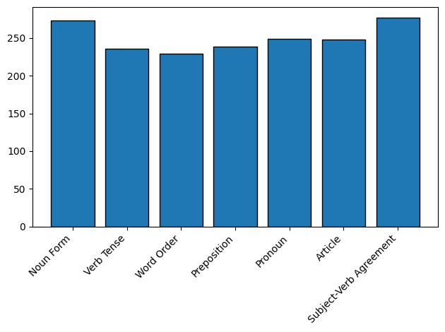

```python
plt.figure()
plt.bar(labels, class_amts, edgecolor="k")
plt.xticks(rotation=45, ha='right')
plt.tight_layout()
plt.show()
```

There is no class imbalance so we don't have to worry about splitting techinques that account for this.

#### Encoding

Now, we will encode Learner_Proficiency as a catgorical variable and Topic, Error_Type, and Grammar_Rule with OHE. Notice that there is no need to normalize the data because there's no numerical data.

```python
# Encode Learner_Proficiency as categorical.
# Github Copilot helped makes sure the order is beginner, intermediate, advanced
proficiency_mapping = {
    'Beginner': 0,
    'Intermediate': 1,
    'Advanced': 2
}
df["Learner_Proficiency"] = df["Learner_Proficiency"].map(proficiency_mapping)

print("Learner_Proficiency mapping:", proficiency_mapping)
```

```
Learner_Proficiency mapping: {'Beginner': 0, 'Intermediate': 1, 'Advanced': 2}
```

```python
df.head(3)
```

|  | Learner_Proficiency | Topic | Original_Sentence | Error_Type | Grammar_Rule |
| --- | --- | --- | --- | --- | --- |
| 0 | 2 | Health | He bought two breads. | Noun Form | Use correct plural form or measure word. |
| 1 | 2 | Health | She go to market yesterday. | Verb Tense | Use past tense for actions completed in the past. |
| 2 | 2 | Sports | Always I drink coffee in morning. | Word Order | Adverbs of frequency go before the main verb. |

```python
# One-hot encode Error_Type, Grammar_Rule, and Topic
df_ohe = pd.get_dummies(df, columns=['Error_Type', 'Grammar_Rule', 'Topic'])
df_ohe
```

|  | Learner_Proficiency | Original_Sentence | Error_Type_Article | Error_Type_Noun Form | Error_Type_Preposition | Error_Type_Pronoun | Error_Type_Subject-Verb Agreement | Error_Type_Verb Tense | Error_Type_Word Order | Grammar_Rule_Adverbs of frequency go before the main verb. | ... | Grammar_Rule_Use subject pronouns in the subject position. | Grammar_Rule_‘Homework’ is uncountable; no article needed. | Grammar_Rule_‘Married to’ is the correct collocation. | Topic_Daily Life | Topic_Education | Topic_Health | Topic_Sports | Topic_Technology | Topic_Travel | Topic_Work |
| --- | --- | --- | --- | --- | --- | --- | --- | --- | --- | --- | --- | --- | --- | --- | --- | --- | --- | --- | --- | --- | --- |
| 0 | 2 | He bought two breads. | False | True | False | False | False | False | False | False | ... | False | False | False | False | False | True | False | False | False | False |
| 1 | 2 | She go to market yesterday. | False | False | False | False | False | True | False | False | ... | False | False | False | False | False | True | False | False | False | False |
| 2 | 2 | Always I drink coffee in morning. | False | False | False | False | False | False | True | True | ... | False | False | False | False | False | False | True | False | False | False |
| 3 | 0 | Always I drink coffee in morning. | False | False | False | False | False | False | True | True | ... | False | False | False | False | False | False | True | False | False | False |
| 4 | 0 | He is married with a doctor. | False | False | True | False | False | False | False | False | ... | False | False | True | False | False | False | False | True | False | False |
| ... | ... | ... | ... | ... | ... | ... | ... | ... | ... | ... | ... | ... | ... | ... | ... | ... | ... | ... | ... | ... | ... |
| 1745 | 2 | I have an homework to finish. | True | False | False | False | False | False | False | False | ... | False | True | False | False | False | False | True | False | False | False |
| 1746 | 2 | Always I drink coffee in morning. | False | False | False | False | False | False | True | True | ... | False | False | False | False | False | False | False | True | False | False |
| 1747 | 0 | I have an homework to finish. | True | False | False | False | False | False | False | False | ... | False | True | False | False | False | False | False | False | False | True |
| 1748 | 0 | She go to market yesterday. | False | False | False | False | False | True | False | False | ... | False | False | False | False | False | False | False | False | False | True |
| 1749 | 2 | The students was happy. | False | False | False | False | True | False | False | False | ... | False | False | False | False | False | True | False | False | False | False |

1750 rows × 23 columns

```python
print(f"\nItems shape: {df_ohe.shape}")
print(f"Items dtypes:\n{df_ohe.dtypes}")
```

```
Items shape: (1750, 23)
Items dtypes:
Learner_Proficiency                                                int64
Original_Sentence                                                 object
Error_Type_Article                                                  bool
Error_Type_Noun Form                                                bool
Error_Type_Preposition                                              bool
Error_Type_Pronoun                                                  bool
Error_Type_Subject-Verb Agreement                                   bool
Error_Type_Verb Tense                                               bool
Error_Type_Word Order                                               bool
Grammar_Rule_Adverbs of frequency go before the main verb.          bool
Grammar_Rule_Plural subjects require plural verbs.                  bool
Grammar_Rule_Use correct plural form or measure word.               bool
Grammar_Rule_Use past tense for actions completed in the past.      bool
Grammar_Rule_Use subject pronouns in the subject position.          bool
Grammar_Rule_‘Homework’ is uncountable; no article needed.          bool
Grammar_Rule_‘Married to’ is the correct collocation.               bool
Topic_Daily Life                                                    bool
Topic_Education                                                     bool
Topic_Health                                                        bool
Topic_Sports                                                        bool
Topic_Technology                                                    bool
Topic_Travel                                                        bool
Topic_Work                                                          bool
dtype: object
```

#### Tokenization

Because our sentences are very short, we decide to use each word as one token. Each punctiation mark will be considered its own token (e.g. 'bread' and '.' will be seperate tokens). This is to make the syste eb able to generalize a little better, otherwise it would always think bread comes with a period (since every example here that uses bread ends with a period)

Since our senteces are short, every word matters. An advantage of this short lenght is that we don't have to cut anything off, so we'll zero pad shorter sentences up to the max ssetence lenght. We determine what this number is below:

```python
# extract each sentence
labels = df_ohe["Original_Sentence"].unique()
sentence_len = []
for c in labels:
    word = 2 # start with 1 to account for the last word not having a space and the period as a seperate token
    for ch in c:
        if ch == ' ':
            word += 1
    sentence_len.append(word)

print("Max words in a sentence: ", max(sentence_len)
   ,"\nMin words in a sentence: ", min(sentence_len))
```

```
Max words in a sentence:  7
Min words in a sentence:  5
```

This means that our maximum length sequence will be 7 and we will 0 pad our 5 token sentences by 2.

```python
# Code adapted from (1). Code adapted from Github Copilot to tokenize punctuation as well
# This code tokenizes each word and punctuation mark. It then 0 pads each sequence.
from tensorflow.keras.preprocessing.text import Tokenizer
from tensorflow.keras.preprocessing import sequence

# Add space before periods so they become separate tokens
df_ohe["Original_Sentence"] = df_ohe["Original_Sentence"].str.replace('.', ' .', regex=False)

# Now tokenize with period kept
tokenizer = Tokenizer(filters='!"#$%&()*+,-/:;<=>?@[\\]^_`{|}~\t\n')
tokenizer.fit_on_texts(df_ohe["Original_Sentence"])

sequences = tokenizer.texts_to_sequences(df_ohe["Original_Sentence"])

max_grammar_length = 7
df_ohe["Original_Sentence"] = list(sequence.pad_sequences(sequences, maxlen=max_grammar_length))
```

#### Final Dataset

```python
df_ohe
```

|  | Learner_Proficiency | Original_Sentence | Error_Type_Article | Error_Type_Noun Form | Error_Type_Preposition | Error_Type_Pronoun | Error_Type_Subject-Verb Agreement | Error_Type_Verb Tense | Error_Type_Word Order | Grammar_Rule_Adverbs of frequency go before the main verb. | ... | Grammar_Rule_Use subject pronouns in the subject position. | Grammar_Rule_‘Homework’ is uncountable; no article needed. | Grammar_Rule_‘Married to’ is the correct collocation. | Topic_Daily Life | Topic_Education | Topic_Health | Topic_Sports | Topic_Technology | Topic_Travel | Topic_Work |
| --- | --- | --- | --- | --- | --- | --- | --- | --- | --- | --- | --- | --- | --- | --- | --- | --- | --- | --- | --- | --- | --- |
| 0 | 2 | [0, 0, 2, 9, 10, 11, 1] | False | True | False | False | False | False | False | False | ... | False | False | False | False | False | True | False | False | False | False |
| 1 | 2 | [0, 26, 27, 3, 28, 29, 1] | False | False | False | False | False | True | False | False | ... | False | False | False | False | False | True | False | False | False | False |
| 2 | 2 | [30, 4, 31, 32, 33, 34, 1] | False | False | False | False | False | False | True | True | ... | False | False | False | False | False | False | True | False | False | False |
| 3 | 0 | [30, 4, 31, 32, 33, 34, 1] | False | False | False | False | False | False | True | True | ... | False | False | False | False | False | False | True | False | False | False |
| 4 | 0 | [2, 21, 22, 23, 24, 25, 1] | False | False | True | False | False | False | False | False | ... | False | False | True | False | False | False | False | True | False | False |
| ... | ... | ... | ... | ... | ... | ... | ... | ... | ... | ... | ... | ... | ... | ... | ... | ... | ... | ... | ... | ... | ... |
| 1745 | 2 | [4, 17, 18, 19, 3, 20, 1] | True | False | False | False | False | False | False | False | ... | False | True | False | False | False | False | True | False | False | False |
| 1746 | 2 | [30, 4, 31, 32, 33, 34, 1] | False | False | False | False | False | False | True | True | ... | False | False | False | False | False | False | False | True | False | False |
| 1747 | 0 | [4, 17, 18, 19, 3, 20, 1] | True | False | False | False | False | False | False | False | ... | False | True | False | False | False | False | False | False | False | True |
| 1748 | 0 | [0, 26, 27, 3, 28, 29, 1] | False | False | False | False | False | True | False | False | ... | False | False | False | False | False | False | False | False | False | True |
| 1749 | 2 | [0, 0, 5, 6, 7, 8, 1] | False | False | False | False | True | False | False | False | ... | False | False | False | False | False | True | False | False | False | False |

1750 rows × 23 columns

Our final dataset contains the same number of instances as the original - 1750 - but half the features. With one-hot encoding, however, there are 23 features.

The dataset contains no missing data.

### Evaluation Metrics

1.2 *Choose and explain what metric(s) you will use to evaluate your algorithm’s performance. You should give a detailed argument for why this (these) metric(s) are appropriate on your data and your business/policy case. That is, why is the metric appropriate for the task (e.g., in terms of the business case for the task). Please note: rarely is accuracy the best evaluation metric to use. Think deeply about an appropriate measure of performance.*

Our algorithm will predict the type of grammatical error a user makes given their incorrect sentence. If the user says "He bought two breads", the system will output that the user's grammatical error is "Noun Form".

This algorithm could be used for companies like Grammarly, Microsoft Word, Google Docs, or any other grammar / text editor service. In particular, it could be used to help user learn English. The user doesn't have to see that they're getting "Noun Form" incorrect, but if this algorithm is part of a larger grammar-checking system, this output would inform the system of which areas of grammar they're getting wrong the most and target improving that area. Thus, knowing that "Noun Form" is the most common mistake for this user, the system can narrow in on what practice problems it can give to help the user learn proper "Noun Form".

There isn't any positive or negative class in the case. None of the error types are more important than the other so it wouldn't make sense to use recall of precision. For example, is the scenario "He bought two bread." being misclassified as "Article" a false positive or a false negative? It's a false positive for the article class. A false negative would be "He bought two bread." being said to not be "Noun Form". However, this is equivalent to it being a false positive for "Article".

Thus, accuracy is a good metric for this situation because it will tell us how many of our classes are correctly attributed. As we saw earlier, there is no class imbalance between the error types so accuracy won't be misleading.

### Train-Test Split

1.3 *Choose the method you will use for dividing your data into training and testing (i.e., are you using Stratified 10-fold cross validation? Shuffle splits? Why?). Explain why your chosen method is appropriate or use more than one method as appropriate. Convince me that your train/test splitting method is a realistic mirroring of how an algorithm would be used in practice.*

The **Stratified 10-fold cross-validation** is the most appropriate method for splitting the data into training and testing. This approach ensures that the class distribution is preserved, maintaining the proportions of each class in every fold. This is particularly important for fair evaluation, as it prevents underrepresented classes from being excluded or poorly represented in some folds. Our dataset is small enough to benefit from this method, yet not so small that it would leave insufficient data for training or testing.

Without stratification, there is a risk that certain classes might be excluded from some folds, leading to biased or unreliable evaluation results. Stratified 10-fold cross-validation addresses this by providing a robust and fair assessment of the model's performance. The data is split into 10 folds, and the model is trained and tested 10 times, with each fold serving as the validation set once while the remaining 9 folds are used for training. This ensures that every data point is utilized for both training and validation, maximizing the utility of the dataset.

This method is particularly well-suited for our dataset, as it allows us to make the most of the available data while still providing a reliable estimate of the model's ability to generalize to unseen data. Although the dataset is relatively small, it is large enough to support this approach without compromising the quality of the evaluation.

First, we need to change the string labels to integers before we instantiate the Stratified K Fold function for our dataset.

```python
# Adapted from Copilot in order to change stringe labels to integers for dataset splitting

error_type_columns = [col for col in df_ohe.columns if col.startswith('Error_Type_')]

y = df_ohe[error_type_columns].idxmax(axis=1) # get the original error type labels

le = LabelEncoder() # to convert string labels to integers
y_encoded = le.fit_transform(y)

# printing out details
print("Target variable distribution:")
print(pd.Series(y).value_counts().sort_index())
print(f"\nTotal samples: {len(y)}") #
print(f"Number of unique classes: {len(y.unique())}")
```

```
Target variable distribution:
Error_Type_Article                   248
Error_Type_Noun Form                 273
Error_Type_Preposition               238
Error_Type_Pronoun                   249
Error_Type_Subject-Verb Agreement    277
Error_Type_Verb Tense                236
Error_Type_Word Order                229
Name: count, dtype: int64

Total samples: 1750
Number of unique classes: 7
```

Now that everything should be prepared for split, we can move onto the part where can **finally** use StratifiedKFold to split the dataset!

```python
# Adapted from Claude AI to implement StratifiedKFold, which maintains class distribution across folds
# Guidance from GeeksforGeeks: https://www.geeksforgeeks.org/stratifiedkfold-in-python/

# instantiating the StratifiedKFold
n_splits = 10
skf = StratifiedKFold(n_splits=n_splits, shuffle=True, random_state=42)

# store fold information
fold_info = {
    'fold': [],
    'train_indices': [],
    'test_indices': [],
    'train_size': [],
    'test_size': []
}

# generating folds and printing out distributions in each fold and overall
for fold, (train_idx, test_idx) in enumerate(skf.split(df_ohe, y_encoded), 1):
    fold_info['fold'].append(fold)
    fold_info['train_indices'].append(train_idx)
    fold_info['test_indices'].append(test_idx)
    fold_info['train_size'].append(len(train_idx))
    fold_info['test_size'].append(len(test_idx))

    print(f"Fold {fold}:")
    print(f"  Training set size: {len(train_idx)} ({len(train_idx)/len(df_ohe)*100:.1f}%)")
    print(f"  Test set size: {len(test_idx)} ({len(test_idx)/len(df_ohe)*100:.1f}%)")

    # check class distribution in train and test sets
    train_dist = pd.Series(y.iloc[train_idx]).value_counts().sort_index()
    test_dist = pd.Series(y.iloc[test_idx]).value_counts().sort_index()

    print(f"  Training set distribution:")
    for error_type, count in train_dist.items():
        print(f"    {error_type}: {count} ({count/len(train_idx)*100:.1f}%)")

    print(f"  Test set distribution:")
    for error_type, count in test_dist.items():
        print(f"    {error_type}: {count} ({count/len(test_idx)*100:.1f}%)")
    print()

# summary is stored into a DataFrame (may remove later, not sure if it's useful for us yet)
fold_summary = pd.DataFrame({
    'Fold': fold_info['fold'],
    'Train Size': fold_info['train_size'],
    'Test Size': fold_info['test_size']
})
```

```
Fold 1:
  Training set size: 1575 (90.0%)
  Test set size: 175 (10.0%)
  Training set distribution:
    Error_Type_Article: 223 (14.2%)
    Error_Type_Noun Form: 245 (15.6%)
    Error_Type_Preposition: 214 (13.6%)
    Error_Type_Pronoun: 224 (14.2%)
    Error_Type_Subject-Verb Agreement: 250 (15.9%)
    Error_Type_Verb Tense: 213 (13.5%)
    Error_Type_Word Order: 206 (13.1%)
  Test set distribution:
    Error_Type_Article: 25 (14.3%)
    Error_Type_Noun Form: 28 (16.0%)
    Error_Type_Preposition: 24 (13.7%)
    Error_Type_Pronoun: 25 (14.3%)
    Error_Type_Subject-Verb Agreement: 27 (15.4%)
    Error_Type_Verb Tense: 23 (13.1%)
    Error_Type_Word Order: 23 (13.1%)

Fold 2:
  Training set size: 1575 (90.0%)
  Test set size: 175 (10.0%)
  Training set distribution:
    Error_Type_Article: 223 (14.2%)
    Error_Type_Noun Form: 245 (15.6%)
    Error_Type_Preposition: 214 (13.6%)
    Error_Type_Pronoun: 224 (14.2%)
    Error_Type_Subject-Verb Agreement: 250 (15.9%)
    Error_Type_Verb Tense: 213 (13.5%)
    Error_Type_Word Order: 206 (13.1%)
  Test set distribution:
    Error_Type_Article: 25 (14.3%)
    Error_Type_Noun Form: 28 (16.0%)
    Error_Type_Preposition: 24 (13.7%)
    Error_Type_Pronoun: 25 (14.3%)
    Error_Type_Subject-Verb Agreement: 27 (15.4%)
    Error_Type_Verb Tense: 23 (13.1%)
    Error_Type_Word Order: 23 (13.1%)

```

[output cut: 144 more lines]

```
    Error_Type_Article: 223 (14.2%)
    Error_Type_Noun Form: 246 (15.6%)
    Error_Type_Preposition: 214 (13.6%)
    Error_Type_Pronoun: 224 (14.2%)
    Error_Type_Subject-Verb Agreement: 249 (15.8%)
    Error_Type_Verb Tense: 213 (13.5%)
    Error_Type_Word Order: 206 (13.1%)
  Test set distribution:
    Error_Type_Article: 25 (14.3%)
    Error_Type_Noun Form: 27 (15.4%)
    Error_Type_Preposition: 24 (13.7%)
    Error_Type_Pronoun: 25 (14.3%)
    Error_Type_Subject-Verb Agreement: 28 (16.0%)
    Error_Type_Verb Tense: 23 (13.1%)
    Error_Type_Word Order: 23 (13.1%)
```

Now that we can see how each class is getting distributed in each fold, we can see the training set size as well as teh test set size! The class proportions are consistent with the overall class distribution in the dataset. Knowing that our dataset is represented in both sets, we can prevent the underrepresented classes from being excluded. It is working as intended, so we should be set for a fair and robust evaluation.

### Note for later: Make a confusion matrix to see which one it gets most wrong

# **2. Modeling**

#### Model 1: CNN Architecture

```python
# Code adapted from (1) and ChatGPT

from tensorflow.keras.models import Model
from tensorflow.keras.layers import Conv1D, MaxPooling1D, GlobalAveragePooling1D
from tensorflow.keras.layers import Flatten, Dense, Dropout
from tensorflow.keras.layers import Embedding, Input, Concatenate
from tensorflow.keras.layers import Subtract
from tensorflow.keras.utils import plot_model
from tensorflow.keras.optimizers import Adam
from tensorflow.keras.optimizers.schedules import ExponentialDecay
import tensorflow as tf

history = []

# Dataset splitting code generated by ChatGPT
for fold in range(n_splits):
    train_idx = fold_info['train_indices'][fold]
    test_idx = fold_info['test_indices'][fold]

    X_train = df_ohe.iloc[train_idx]
    X_test = df_ohe.iloc[test_idx]

    y_train = y_encoded[train_idx]
    y_test = y_encoded[test_idx]

    X_train_seq = np.array(X_train["Original_Sentence"].tolist())
    X_test_seq  = np.array(X_test["Original_Sentence"].tolist())

    EMBED_SIZE = 50
    # vocab size calculation generated by ChatGPT
    vocab_size = max(max(seq) for seq in df_ohe["Original_Sentence"]) + 1
    sequence_input = Input(shape=(max_grammar_length, ))

    embedded_sequences = Embedding(vocab_size,
                    EMBED_SIZE,
                    input_length=max_grammar_length)(sequence_input)

    x = Conv1D(16, 3, activation='relu',
              kernel_initializer='he_uniform')(embedded_sequences)

    x = MaxPooling1D(2)(x)
    x = Dropout(0.7)(x)

    x = Conv1D(16, 2, activation='relu',
              kernel_initializer='he_uniform')(x)

    x = Dropout(0.7)(x)

    x_mean = GlobalAveragePooling1D()(x)

    x_tmp = Subtract()([x,x_mean])
    x_std = GlobalAveragePooling1D()(x_tmp**2)

    x = Concatenate(name='concat_1')([x_mean,x_std])

    x = Dense(16, activation='relu',
              kernel_initializer='he_uniform')(x)

    x = Dropout(0.7)(x)

    # activation modified by ChatGPT
    preds = Dense(7, activation='softmax',
                  kernel_initializer='glorot_uniform')(x)

    model = Model(sequence_input, preds)

    lr_schedule = ExponentialDecay(
      initial_learning_rate=0.001,
      decay_steps=10000,
      decay_rate=0.95,
      staircase=True)

    opt = Adam(epsilon=0.0001, learning_rate=lr_schedule)
    model.compile(loss='sparse_categorical_crossentropy',
                  optimizer=opt,
                  metrics=['acc'])

    tmp = model.fit(X_train_seq, y_train, epochs=20,
                    batch_size=64,
                    validation_data=(X_test_seq, y_test))
    history.append(tmp)
```

```
25/25 ━━━━━━━━━━━━━━━━━━━━ 9s 159ms/step - acc: 0.1614 - loss: 1.9490 - val_acc: 0.2914 - val_loss: 1.9004
25/25 ━━━━━━━━━━━━━━━━━━━━ 0s 5ms/step - acc: 0.1720 - loss: 1.8945 - val_acc: 0.4343 - val_loss: 1.8585
25/25 ━━━━━━━━━━━━━━━━━━━━ 0s 5ms/step - acc: 0.2602 - loss: 1.8490 - val_acc: 0.7314 - val_loss: 1.7994
25/25 ━━━━━━━━━━━━━━━━━━━━ 0s 5ms/step - acc: 0.2512 - loss: 1.8261 - val_acc: 0.8629 - val_loss: 1.7377
25/25 ━━━━━━━━━━━━━━━━━━━━ 0s 5ms/step - acc: 0.2894 - loss: 1.7949 - val_acc: 0.8629 - val_loss: 1.6631
25/25 ━━━━━━━━━━━━━━━━━━━━ 0s 5ms/step - acc: 0.3125 - loss: 1.7685 - val_acc: 0.8629 - val_loss: 1.6023
25/25 ━━━━━━━━━━━━━━━━━━━━ 0s 5ms/step - acc: 0.3462 - loss: 1.7003 - val_acc: 0.8629 - val_loss: 1.5266
25/25 ━━━━━━━━━━━━━━━━━━━━ 0s 5ms/step - acc: 0.3388 - loss: 1.6894 - val_acc: 0.8629 - val_loss: 1.4667
25/25 ━━━━━━━━━━━━━━━━━━━━ 0s 5ms/step - acc: 0.3640 - loss: 1.6338 - val_acc: 0.8629 - val_loss: 1.4007
25/25 ━━━━━━━━━━━━━━━━━━━━ 0s 5ms/step - acc: 0.3560 - loss: 1.6449 - val_acc: 0.8629 - val_loss: 1.3508
25/25 ━━━━━━━━━━━━━━━━━━━━ 0s 5ms/step - acc: 0.3624 - loss: 1.5739 - val_acc: 0.8629 - val_loss: 1.3026
25/25 ━━━━━━━━━━━━━━━━━━━━ 0s 5ms/step - acc: 0.3684 - loss: 1.5744 - val_acc: 0.8629 - val_loss: 1.2634
25/25 ━━━━━━━━━━━━━━━━━━━━ 0s 5ms/step - acc: 0.3681 - loss: 1.5651 - val_acc: 0.8629 - val_loss: 1.2327
25/25 ━━━━━━━━━━━━━━━━━━━━ 0s 5ms/step - acc: 0.3901 - loss: 1.5189 - val_acc: 0.8629 - val_loss: 1.2034
25/25 ━━━━━━━━━━━━━━━━━━━━ 0s 5ms/step - acc: 0.3781 - loss: 1.5046 - val_acc: 0.8629 - val_loss: 1.1513
25/25 ━━━━━━━━━━━━━━━━━━━━ 0s 5ms/step - acc: 0.3891 - loss: 1.4748 - val_acc: 0.8629 - val_loss: 1.1273
25/25 ━━━━━━━━━━━━━━━━━━━━ 0s 5ms/step - acc: 0.4110 - loss: 1.4788 - val_acc: 0.8629 - val_loss: 1.1002
25/25 ━━━━━━━━━━━━━━━━━━━━ 0s 5ms/step - acc: 0.3994 - loss: 1.4683 - val_acc: 0.8629 - val_loss: 1.0752
25/25 ━━━━━━━━━━━━━━━━━━━━ 0s 5ms/step - acc: 0.4250 - loss: 1.4472 - val_acc: 0.7086 - val_loss: 1.0492
25/25 ━━━━━━━━━━━━━━━━━━━━ 0s 5ms/step - acc: 0.3892 - loss: 1.4545 - val_acc: 0.8629 - val_loss: 1.0286
25/25 ━━━━━━━━━━━━━━━━━━━━ 7s 139ms/step - acc: 0.1358 - loss: 1.9512 - val_acc: 0.4286 - val_loss: 1.8905
25/25 ━━━━━━━━━━━━━━━━━━━━ 0s 5ms/step - acc: 0.1868 - loss: 1.8920 - val_acc: 0.7200 - val_loss: 1.8343
25/25 ━━━━━━━━━━━━━━━━━━━━ 0s 5ms/step - acc: 0.1865 - loss: 1.8706 - val_acc: 0.7200 - val_loss: 1.7782
25/25 ━━━━━━━━━━━━━━━━━━━━ 0s 5ms/step - acc: 0.2318 - loss: 1.8288 - val_acc: 1.0000 - val_loss: 1.7114
25/25 ━━━━━━━━━━━━━━━━━━━━ 0s 5ms/step - acc: 0.3013 - loss: 1.7859 - val_acc: 0.8571 - val_loss: 1.6408
25/25 ━━━━━━━━━━━━━━━━━━━━ 0s 5ms/step - acc: 0.3005 - loss: 1.7724 - val_acc: 0.8629 - val_loss: 1.5551
25/25 ━━━━━━━━━━━━━━━━━━━━ 0s 5ms/step - acc: 0.3527 - loss: 1.7128 - val_acc: 0.8629 - val_loss: 1.4719
25/25 ━━━━━━━━━━━━━━━━━━━━ 0s 5ms/step - acc: 0.3477 - loss: 1.7112 - val_acc: 0.8629 - val_loss: 1.4065
25/25 ━━━━━━━━━━━━━━━━━━━━ 0s 5ms/step - acc: 0.3630 - loss: 1.6615 - val_acc: 0.8629 - val_loss: 1.3624
25/25 ━━━━━━━━━━━━━━━━━━━━ 0s 5ms/step - acc: 0.4000 - loss: 1.6434 - val_acc: 0.8629 - val_loss: 1.2848
25/25 ━━━━━━━━━━━━━━━━━━━━ 0s 5ms/step - acc: 0.3642 - loss: 1.6296 - val_acc: 0.8629 - val_loss: 1.2186
25/25 ━━━━━━━━━━━━━━━━━━━━ 0s 5ms/step - acc: 0.3915 - loss: 1.5678 - val_acc: 0.8629 - val_loss: 1.1664
25/25 ━━━━━━━━━━━━━━━━━━━━ 0s 5ms/step - acc: 0.4164 - loss: 1.5255 - val_acc: 0.8629 - val_loss: 1.1209
25/25 ━━━━━━━━━━━━━━━━━━━━ 0s 5ms/step - acc: 0.4069 - loss: 1.5403 - val_acc: 0.8629 - val_loss: 1.0748
25/25 ━━━━━━━━━━━━━━━━━━━━ 0s 5ms/step - acc: 0.3756 - loss: 1.5180 - val_acc: 0.8629 - val_loss: 1.0423
25/25 ━━━━━━━━━━━━━━━━━━━━ 0s 5ms/step - acc: 0.4146 - loss: 1.5070 - val_acc: 0.8629 - val_loss: 1.0060
25/25 ━━━━━━━━━━━━━━━━━━━━ 0s 5ms/step - acc: 0.3946 - loss: 1.4978 - val_acc: 0.8629 - val_loss: 0.9874
25/25 ━━━━━━━━━━━━━━━━━━━━ 0s 5ms/step - acc: 0.4357 - loss: 1.4614 - val_acc: 0.8629 - val_loss: 0.9712
25/25 ━━━━━━━━━━━━━━━━━━━━ 0s 5ms/step - acc: 0.4328 - loss: 1.4376 - val_acc: 0.8629 - val_loss: 0.9699
25/25 ━━━━━━━━━━━━━━━━━━━━ 0s 5ms/step - acc: 0.4712 - loss: 1.4294 - val_acc: 0.8629 - val_loss: 0.9432
```

[output cut: 145 more lines]

```
25/25 ━━━━━━━━━━━━━━━━━━━━ 0s 5ms/step - acc: 0.2835 - loss: 1.7615 - val_acc: 0.7200 - val_loss: 1.5980
25/25 ━━━━━━━━━━━━━━━━━━━━ 0s 5ms/step - acc: 0.3098 - loss: 1.7413 - val_acc: 0.7200 - val_loss: 1.5516
25/25 ━━━━━━━━━━━━━━━━━━━━ 0s 5ms/step - acc: 0.3045 - loss: 1.7193 - val_acc: 0.7200 - val_loss: 1.4495
25/25 ━━━━━━━━━━━━━━━━━━━━ 0s 5ms/step - acc: 0.3432 - loss: 1.6566 - val_acc: 0.7200 - val_loss: 1.3550
25/25 ━━━━━━━━━━━━━━━━━━━━ 0s 5ms/step - acc: 0.3390 - loss: 1.6570 - val_acc: 0.7200 - val_loss: 1.2874
25/25 ━━━━━━━━━━━━━━━━━━━━ 0s 5ms/step - acc: 0.3574 - loss: 1.5822 - val_acc: 0.7200 - val_loss: 1.2148
25/25 ━━━━━━━━━━━━━━━━━━━━ 0s 5ms/step - acc: 0.3418 - loss: 1.5724 - val_acc: 0.7200 - val_loss: 1.1789
25/25 ━━━━━━━━━━━━━━━━━━━━ 0s 5ms/step - acc: 0.3726 - loss: 1.5836 - val_acc: 0.7200 - val_loss: 1.1555
25/25 ━━━━━━━━━━━━━━━━━━━━ 0s 5ms/step - acc: 0.3772 - loss: 1.5361 - val_acc: 0.7200 - val_loss: 1.1172
25/25 ━━━━━━━━━━━━━━━━━━━━ 0s 5ms/step - acc: 0.3740 - loss: 1.5048 - val_acc: 0.7200 - val_loss: 1.0795
25/25 ━━━━━━━━━━━━━━━━━━━━ 0s 5ms/step - acc: 0.3654 - loss: 1.5049 - val_acc: 0.7200 - val_loss: 1.0357
25/25 ━━━━━━━━━━━━━━━━━━━━ 0s 5ms/step - acc: 0.3719 - loss: 1.5142 - val_acc: 0.7200 - val_loss: 1.0134
25/25 ━━━━━━━━━━━━━━━━━━━━ 0s 5ms/step - acc: 0.4055 - loss: 1.4453 - val_acc: 0.7200 - val_loss: 0.9878
25/25 ━━━━━━━━━━━━━━━━━━━━ 0s 5ms/step - acc: 0.3754 - loss: 1.4654 - val_acc: 0.7200 - val_loss: 0.9608
25/25 ━━━━━━━━━━━━━━━━━━━━ 0s 5ms/step - acc: 0.3931 - loss: 1.4195 - val_acc: 0.7200 - val_loss: 0.9419
```

#### Model 2: CNN Architecture With More Filters

```python
history2 = []

# Dataset splitting code generated by ChatGPT
for fold in range(n_splits):
    train_idx = fold_info['train_indices'][fold]
    test_idx = fold_info['test_indices'][fold]

    X_train = df_ohe.iloc[train_idx]
    X_test = df_ohe.iloc[test_idx]

    y_train = y_encoded[train_idx]
    y_test = y_encoded[test_idx]

    X_train_seq = np.array(X_train["Original_Sentence"].tolist())
    X_test_seq  = np.array(X_test["Original_Sentence"].tolist())

    EMBED_SIZE = 50
    # vocab size calculation generated by ChatGPT
    vocab_size = max(max(seq) for seq in df_ohe["Original_Sentence"]) + 1
    sequence_input = Input(shape=(max_grammar_length, ))

    embedded_sequences = Embedding(vocab_size,
                    EMBED_SIZE,
                    input_length=max_grammar_length)(sequence_input)

    x = Conv1D(32, 3, activation='relu',
              kernel_initializer='he_uniform')(embedded_sequences)

    x = MaxPooling1D(2)(x)
    x = Dropout(0.75)(x)

    x = Conv1D(32, 2, activation='relu',
              kernel_initializer='he_uniform')(x)

    x = Dropout(0.75)(x)

    x_mean = GlobalAveragePooling1D()(x)

    x_tmp = Subtract()([x,x_mean])
    x_std = GlobalAveragePooling1D()(x_tmp**2)

    x = Concatenate(name='concat_1')([x_mean,x_std])

    x = Dense(32, activation='relu',
              kernel_initializer='he_uniform')(x)

    x = Dropout(0.75)(x)

    # activation modified by ChatGPT
    preds = Dense(7, activation='softmax',
                  kernel_initializer='glorot_uniform')(x)

    model2 = Model(sequence_input, preds)

    lr_schedule = ExponentialDecay(
      initial_learning_rate=0.001,
      decay_steps=10000,
      decay_rate=0.95,
      staircase=True)

    opt = Adam(epsilon=0.0001, learning_rate=lr_schedule)
    model2.compile(loss='sparse_categorical_crossentropy',
                  optimizer=opt,
                  metrics=['acc'])

    tmp = model2.fit(X_train_seq, y_train, epochs=20,
                    batch_size=64,
                    validation_data=(X_test_seq, y_test))
    history2.append(tmp)
```

```
25/25 ━━━━━━━━━━━━━━━━━━━━ 8s 160ms/step - acc: 0.1651 - loss: 1.9604 - val_acc: 0.5829 - val_loss: 1.9030
25/25 ━━━━━━━━━━━━━━━━━━━━ 0s 5ms/step - acc: 0.1869 - loss: 1.9099 - val_acc: 0.8686 - val_loss: 1.8593
25/25 ━━━━━━━━━━━━━━━━━━━━ 0s 5ms/step - acc: 0.2153 - loss: 1.8731 - val_acc: 0.8686 - val_loss: 1.7932
25/25 ━━━━━━━━━━━━━━━━━━━━ 0s 5ms/step - acc: 0.2354 - loss: 1.8464 - val_acc: 0.8686 - val_loss: 1.6965
25/25 ━━━━━━━━━━━━━━━━━━━━ 0s 5ms/step - acc: 0.2607 - loss: 1.8026 - val_acc: 0.8686 - val_loss: 1.6114
25/25 ━━━━━━━━━━━━━━━━━━━━ 0s 5ms/step - acc: 0.2857 - loss: 1.7595 - val_acc: 0.8686 - val_loss: 1.5184
25/25 ━━━━━━━━━━━━━━━━━━━━ 0s 5ms/step - acc: 0.3508 - loss: 1.6883 - val_acc: 0.8686 - val_loss: 1.4352
25/25 ━━━━━━━━━━━━━━━━━━━━ 0s 5ms/step - acc: 0.3577 - loss: 1.6736 - val_acc: 0.8686 - val_loss: 1.3790
25/25 ━━━━━━━━━━━━━━━━━━━━ 0s 4ms/step - acc: 0.3381 - loss: 1.6550 - val_acc: 0.8686 - val_loss: 1.3305
25/25 ━━━━━━━━━━━━━━━━━━━━ 0s 5ms/step - acc: 0.3936 - loss: 1.5910 - val_acc: 0.8686 - val_loss: 1.2682
25/25 ━━━━━━━━━━━━━━━━━━━━ 0s 5ms/step - acc: 0.4039 - loss: 1.5174 - val_acc: 0.8686 - val_loss: 1.2143
25/25 ━━━━━━━━━━━━━━━━━━━━ 0s 4ms/step - acc: 0.4306 - loss: 1.4758 - val_acc: 0.8686 - val_loss: 1.1527
25/25 ━━━━━━━━━━━━━━━━━━━━ 0s 5ms/step - acc: 0.4578 - loss: 1.4314 - val_acc: 0.8686 - val_loss: 1.0814
25/25 ━━━━━━━━━━━━━━━━━━━━ 0s 4ms/step - acc: 0.4187 - loss: 1.4457 - val_acc: 0.8686 - val_loss: 1.0242
25/25 ━━━━━━━━━━━━━━━━━━━━ 0s 4ms/step - acc: 0.4604 - loss: 1.3676 - val_acc: 0.8686 - val_loss: 0.9872
25/25 ━━━━━━━━━━━━━━━━━━━━ 0s 4ms/step - acc: 0.4530 - loss: 1.3631 - val_acc: 0.8686 - val_loss: 0.9361
25/25 ━━━━━━━━━━━━━━━━━━━━ 0s 4ms/step - acc: 0.4865 - loss: 1.3041 - val_acc: 0.8686 - val_loss: 0.8876
25/25 ━━━━━━━━━━━━━━━━━━━━ 0s 4ms/step - acc: 0.4753 - loss: 1.3564 - val_acc: 0.8686 - val_loss: 0.8638
25/25 ━━━━━━━━━━━━━━━━━━━━ 0s 4ms/step - acc: 0.4977 - loss: 1.2606 - val_acc: 0.8686 - val_loss: 0.8051
25/25 ━━━━━━━━━━━━━━━━━━━━ 0s 5ms/step - acc: 0.5066 - loss: 1.2501 - val_acc: 0.8686 - val_loss: 0.7721
25/25 ━━━━━━━━━━━━━━━━━━━━ 7s 134ms/step - acc: 0.1630 - loss: 1.9578 - val_acc: 0.8571 - val_loss: 1.8991
25/25 ━━━━━━━━━━━━━━━━━━━━ 0s 5ms/step - acc: 0.2152 - loss: 1.8952 - val_acc: 0.8571 - val_loss: 1.8534
25/25 ━━━━━━━━━━━━━━━━━━━━ 0s 5ms/step - acc: 0.2800 - loss: 1.8575 - val_acc: 0.8571 - val_loss: 1.7796
25/25 ━━━━━━━━━━━━━━━━━━━━ 0s 5ms/step - acc: 0.3079 - loss: 1.8202 - val_acc: 0.7029 - val_loss: 1.6885
25/25 ━━━━━━━━━━━━━━━━━━━━ 0s 5ms/step - acc: 0.3472 - loss: 1.7744 - val_acc: 0.7029 - val_loss: 1.5964
25/25 ━━━━━━━━━━━━━━━━━━━━ 0s 5ms/step - acc: 0.3635 - loss: 1.7406 - val_acc: 0.7029 - val_loss: 1.5466
25/25 ━━━━━━━━━━━━━━━━━━━━ 0s 5ms/step - acc: 0.3798 - loss: 1.6708 - val_acc: 0.7029 - val_loss: 1.4559
25/25 ━━━━━━━━━━━━━━━━━━━━ 0s 5ms/step - acc: 0.4232 - loss: 1.6120 - val_acc: 0.7029 - val_loss: 1.3456
25/25 ━━━━━━━━━━━━━━━━━━━━ 0s 5ms/step - acc: 0.3967 - loss: 1.5736 - val_acc: 0.7029 - val_loss: 1.2502
25/25 ━━━━━━━━━━━━━━━━━━━━ 0s 5ms/step - acc: 0.3849 - loss: 1.5400 - val_acc: 0.7029 - val_loss: 1.1640
25/25 ━━━━━━━━━━━━━━━━━━━━ 0s 5ms/step - acc: 0.4349 - loss: 1.4988 - val_acc: 0.7029 - val_loss: 1.1038
25/25 ━━━━━━━━━━━━━━━━━━━━ 0s 5ms/step - acc: 0.4438 - loss: 1.4426 - val_acc: 0.7029 - val_loss: 1.0492
25/25 ━━━━━━━━━━━━━━━━━━━━ 0s 5ms/step - acc: 0.4627 - loss: 1.4191 - val_acc: 0.7029 - val_loss: 0.9869
25/25 ━━━━━━━━━━━━━━━━━━━━ 0s 5ms/step - acc: 0.4486 - loss: 1.4036 - val_acc: 0.7029 - val_loss: 0.9472
25/25 ━━━━━━━━━━━━━━━━━━━━ 0s 5ms/step - acc: 0.4842 - loss: 1.3460 - val_acc: 0.7029 - val_loss: 0.9039
25/25 ━━━━━━━━━━━━━━━━━━━━ 0s 5ms/step - acc: 0.4756 - loss: 1.3213 - val_acc: 0.7029 - val_loss: 0.8540
25/25 ━━━━━━━━━━━━━━━━━━━━ 0s 5ms/step - acc: 0.5025 - loss: 1.2771 - val_acc: 0.7029 - val_loss: 0.8106
25/25 ━━━━━━━━━━━━━━━━━━━━ 0s 5ms/step - acc: 0.4849 - loss: 1.2992 - val_acc: 0.7029 - val_loss: 0.7816
25/25 ━━━━━━━━━━━━━━━━━━━━ 0s 5ms/step - acc: 0.5087 - loss: 1.2468 - val_acc: 0.7029 - val_loss: 0.7607
25/25 ━━━━━━━━━━━━━━━━━━━━ 0s 5ms/step - acc: 0.5028 - loss: 1.2029 - val_acc: 0.7029 - val_loss: 0.7365
```

[output cut: 145 more lines]

```
25/25 ━━━━━━━━━━━━━━━━━━━━ 0s 5ms/step - acc: 0.3034 - loss: 1.7140 - val_acc: 0.8629 - val_loss: 1.5266
25/25 ━━━━━━━━━━━━━━━━━━━━ 0s 5ms/step - acc: 0.3557 - loss: 1.6823 - val_acc: 1.0000 - val_loss: 1.4317
25/25 ━━━━━━━━━━━━━━━━━━━━ 0s 5ms/step - acc: 0.4193 - loss: 1.6069 - val_acc: 0.8571 - val_loss: 1.3323
25/25 ━━━━━━━━━━━━━━━━━━━━ 0s 5ms/step - acc: 0.4443 - loss: 1.5211 - val_acc: 1.0000 - val_loss: 1.2135
25/25 ━━━━━━━━━━━━━━━━━━━━ 0s 4ms/step - acc: 0.4264 - loss: 1.5781 - val_acc: 0.8571 - val_loss: 1.1606
25/25 ━━━━━━━━━━━━━━━━━━━━ 0s 5ms/step - acc: 0.4868 - loss: 1.4890 - val_acc: 0.8571 - val_loss: 1.0739
25/25 ━━━━━━━━━━━━━━━━━━━━ 0s 5ms/step - acc: 0.4659 - loss: 1.4499 - val_acc: 0.8571 - val_loss: 1.0065
25/25 ━━━━━━━━━━━━━━━━━━━━ 0s 4ms/step - acc: 0.4953 - loss: 1.3683 - val_acc: 0.8571 - val_loss: 0.9339
25/25 ━━━━━━━━━━━━━━━━━━━━ 0s 5ms/step - acc: 0.5086 - loss: 1.3499 - val_acc: 0.8571 - val_loss: 0.8901
25/25 ━━━━━━━━━━━━━━━━━━━━ 0s 5ms/step - acc: 0.5066 - loss: 1.2869 - val_acc: 0.8571 - val_loss: 0.8314
25/25 ━━━━━━━━━━━━━━━━━━━━ 0s 5ms/step - acc: 0.5561 - loss: 1.2488 - val_acc: 0.8571 - val_loss: 0.7842
25/25 ━━━━━━━━━━━━━━━━━━━━ 0s 5ms/step - acc: 0.5258 - loss: 1.2853 - val_acc: 0.8571 - val_loss: 0.7509
25/25 ━━━━━━━━━━━━━━━━━━━━ 0s 5ms/step - acc: 0.5431 - loss: 1.2330 - val_acc: 0.8571 - val_loss: 0.7251
25/25 ━━━━━━━━━━━━━━━━━━━━ 0s 5ms/step - acc: 0.5341 - loss: 1.2076 - val_acc: 0.8571 - val_loss: 0.7051
25/25 ━━━━━━━━━━━━━━━━━━━━ 0s 4ms/step - acc: 0.5217 - loss: 1.2566 - val_acc: 0.8571 - val_loss: 0.6960
```

#### Model 3: Transformer Architecture

```python
from tensorflow.keras.layers import MultiHeadAttention, LayerNormalization
from tensorflow.keras import Sequential
from tensorflow.keras.layers import Layer
from sklearn import metrics as mt

class TransformerBlock(Layer):
    def __init__(self, embed_dim, num_heads, ff_dim, rate=0.4):
        super().__init__()
        self.att = MultiHeadAttention(num_heads=num_heads,
                                      key_dim=embed_dim)

        self.ffn = Sequential()
        self.ffn.add( Dense(ff_dim, activation='relu') )
        self.ffn.add( Dense(embed_dim) )

        self.layernorm1 = LayerNormalization(epsilon=1e-6)
        self.layernorm2 = LayerNormalization(epsilon=1e-6)
        self.dropout1 = Dropout(rate)
        self.dropout2 = Dropout(rate)

    # training default adapted from ChatGPT
    def call(self, inputs, training=None):
        attn_output = self.att(inputs, inputs)

        out1 = self.layernorm1(inputs + attn_output)

        out1 = self.dropout1(out1, training=training)

        ffn_output = self.ffn(out1)
        out2 = self.layernorm2(out1 + ffn_output)

        out2 = self.dropout2(out2, training=training)
        return out2

class TokenAndPositionEmbedding(Layer):
    def __init__(self, maxlen, vocab_size, embed_dim):
        super().__init__()
        self.token_emb = Embedding(input_dim=vocab_size,
                                   output_dim=embed_dim)
        self.pos_emb = Embedding(input_dim=maxlen,
                                 output_dim=embed_dim)

    def call(self, x):
        maxlen = tf.shape(x)[-1]
        positions = tf.range(start=0, limit=maxlen, delta=1)
        positions = self.pos_emb(positions)
        x = self.token_emb(x)
        return x + positions
```

```python
history3 = []

# Dataset splitting code generated by ChatGPT
vocab_size = max(max(seq) for seq in df_ohe["Original_Sentence"]) + 1

for fold in range(n_splits):
    train_idx = fold_info['train_indices'][fold]
    test_idx = fold_info['test_indices'][fold]

    X_train = df_ohe.iloc[train_idx]
    X_test = df_ohe.iloc[test_idx]

    y_train = y_encoded[train_idx]
    y_test = y_encoded[test_idx]

    X_train_seq = np.array(X_train["Original_Sentence"].tolist())
    X_test_seq  = np.array(X_test["Original_Sentence"].tolist())

    embed_dim = 30
    num_heads = 1
    ff_dim = 50

    inputs = Input(shape=(max_grammar_length, ))
    x = TokenAndPositionEmbedding(max_grammar_length, vocab_size, embed_dim)(inputs)
    x = TransformerBlock(embed_dim, num_heads, ff_dim)(x)

    x = GlobalAveragePooling1D()(x)
    x = Dropout(0.6)(x)
    x = Dense(11, activation='relu')(x)
    x = Dropout(0.6)(x)
    outputs = Dense(7, activation='softmax',
                  kernel_initializer='glorot_uniform')(x)

    model_xformer = Model(inputs=inputs, outputs=outputs)

    lr_schedule = ExponentialDecay(
      initial_learning_rate=0.001,
      decay_steps=10000,
      decay_rate=0.95,
      staircase=True)

    opt = Adam(epsilon=0.0001, learning_rate=lr_schedule)
    model_xformer.compile(optimizer=opt,
                      loss='sparse_categorical_crossentropy',
                      metrics=['accuracy'])

    tmp = model_xformer.fit(
        X_train_seq, y_train, batch_size=64, epochs=10,
        validation_data=(X_test_seq, y_test)
    )
    history3.append(tmp)
```

```
25/25 ━━━━━━━━━━━━━━━━━━━━ 13s 261ms/step - accuracy: 0.1734 - loss: 2.3719 - val_accuracy: 0.5429 - val_loss: 1.8708
25/25 ━━━━━━━━━━━━━━━━━━━━ 0s 5ms/step - accuracy: 0.2173 - loss: 1.9136 - val_accuracy: 0.7029 - val_loss: 1.6149
25/25 ━━━━━━━━━━━━━━━━━━━━ 0s 5ms/step - accuracy: 0.2875 - loss: 1.7454 - val_accuracy: 0.8629 - val_loss: 1.1687
25/25 ━━━━━━━━━━━━━━━━━━━━ 0s 5ms/step - accuracy: 0.3497 - loss: 1.5723 - val_accuracy: 1.0000 - val_loss: 0.8391
25/25 ━━━━━━━━━━━━━━━━━━━━ 0s 5ms/step - accuracy: 0.4408 - loss: 1.3797 - val_accuracy: 1.0000 - val_loss: 0.6070
25/25 ━━━━━━━━━━━━━━━━━━━━ 0s 5ms/step - accuracy: 0.4946 - loss: 1.2425 - val_accuracy: 1.0000 - val_loss: 0.4739
25/25 ━━━━━━━━━━━━━━━━━━━━ 0s 5ms/step - accuracy: 0.5209 - loss: 1.1768 - val_accuracy: 1.0000 - val_loss: 0.4238
25/25 ━━━━━━━━━━━━━━━━━━━━ 0s 5ms/step - accuracy: 0.5077 - loss: 1.1923 - val_accuracy: 1.0000 - val_loss: 0.3507
25/25 ━━━━━━━━━━━━━━━━━━━━ 0s 5ms/step - accuracy: 0.5384 - loss: 1.1257 - val_accuracy: 1.0000 - val_loss: 0.2952
25/25 ━━━━━━━━━━━━━━━━━━━━ 0s 5ms/step - accuracy: 0.5584 - loss: 1.0688 - val_accuracy: 1.0000 - val_loss: 0.2682
25/25 ━━━━━━━━━━━━━━━━━━━━ 12s 213ms/step - accuracy: 0.1502 - loss: 2.2485 - val_accuracy: 0.2971 - val_loss: 1.9126
25/25 ━━━━━━━━━━━━━━━━━━━━ 0s 5ms/step - accuracy: 0.2204 - loss: 1.8815 - val_accuracy: 0.7314 - val_loss: 1.4036
25/25 ━━━━━━━━━━━━━━━━━━━━ 0s 5ms/step - accuracy: 0.3020 - loss: 1.6661 - val_accuracy: 1.0000 - val_loss: 1.0014
25/25 ━━━━━━━━━━━━━━━━━━━━ 0s 5ms/step - accuracy: 0.3973 - loss: 1.4470 - val_accuracy: 1.0000 - val_loss: 0.6938
25/25 ━━━━━━━━━━━━━━━━━━━━ 0s 5ms/step - accuracy: 0.4627 - loss: 1.3049 - val_accuracy: 1.0000 - val_loss: 0.5597
25/25 ━━━━━━━━━━━━━━━━━━━━ 0s 5ms/step - accuracy: 0.5424 - loss: 1.1764 - val_accuracy: 1.0000 - val_loss: 0.3926
25/25 ━━━━━━━━━━━━━━━━━━━━ 0s 5ms/step - accuracy: 0.5767 - loss: 1.0796 - val_accuracy: 1.0000 - val_loss: 0.2989
25/25 ━━━━━━━━━━━━━━━━━━━━ 0s 5ms/step - accuracy: 0.5831 - loss: 1.0556 - val_accuracy: 1.0000 - val_loss: 0.2509
25/25 ━━━━━━━━━━━━━━━━━━━━ 0s 5ms/step - accuracy: 0.5986 - loss: 1.0324 - val_accuracy: 1.0000 - val_loss: 0.2353
25/25 ━━━━━━━━━━━━━━━━━━━━ 0s 5ms/step - accuracy: 0.6534 - loss: 0.9495 - val_accuracy: 1.0000 - val_loss: 0.2049
25/25 ━━━━━━━━━━━━━━━━━━━━ 11s 214ms/step - accuracy: 0.1686 - loss: 2.2617 - val_accuracy: 0.1429 - val_loss: 1.9062
25/25 ━━━━━━━━━━━━━━━━━━━━ 0s 5ms/step - accuracy: 0.2308 - loss: 1.8670 - val_accuracy: 0.5657 - val_loss: 1.4097
25/25 ━━━━━━━━━━━━━━━━━━━━ 0s 5ms/step - accuracy: 0.3039 - loss: 1.6493 - val_accuracy: 1.0000 - val_loss: 1.0017
25/25 ━━━━━━━━━━━━━━━━━━━━ 0s 5ms/step - accuracy: 0.3852 - loss: 1.4841 - val_accuracy: 1.0000 - val_loss: 0.7398
25/25 ━━━━━━━━━━━━━━━━━━━━ 0s 5ms/step - accuracy: 0.4195 - loss: 1.3602 - val_accuracy: 1.0000 - val_loss: 0.5996
25/25 ━━━━━━━━━━━━━━━━━━━━ 0s 5ms/step - accuracy: 0.4670 - loss: 1.2453 - val_accuracy: 1.0000 - val_loss: 0.4638
25/25 ━━━━━━━━━━━━━━━━━━━━ 0s 5ms/step - accuracy: 0.4936 - loss: 1.1945 - val_accuracy: 1.0000 - val_loss: 0.3960
25/25 ━━━━━━━━━━━━━━━━━━━━ 0s 5ms/step - accuracy: 0.5127 - loss: 1.1321 - val_accuracy: 1.0000 - val_loss: 0.3268
25/25 ━━━━━━━━━━━━━━━━━━━━ 0s 5ms/step - accuracy: 0.5465 - loss: 1.0349 - val_accuracy: 1.0000 - val_loss: 0.2683
25/25 ━━━━━━━━━━━━━━━━━━━━ 0s 5ms/step - accuracy: 0.5603 - loss: 1.0408 - val_accuracy: 1.0000 - val_loss: 0.2434
25/25 ━━━━━━━━━━━━━━━━━━━━ 11s 217ms/step - accuracy: 0.1601 - loss: 2.2725 - val_accuracy: 0.7257 - val_loss: 1.7164
25/25 ━━━━━━━━━━━━━━━━━━━━ 0s 5ms/step - accuracy: 0.2233 - loss: 1.8725 - val_accuracy: 0.7314 - val_loss: 1.2788
25/25 ━━━━━━━━━━━━━━━━━━━━ 0s 5ms/step - accuracy: 0.3036 - loss: 1.6509 - val_accuracy: 0.8686 - val_loss: 0.9045
25/25 ━━━━━━━━━━━━━━━━━━━━ 0s 5ms/step - accuracy: 0.3743 - loss: 1.4781 - val_accuracy: 1.0000 - val_loss: 0.7211
25/25 ━━━━━━━━━━━━━━━━━━━━ 0s 6ms/step - accuracy: 0.4115 - loss: 1.3728 - val_accuracy: 0.8686 - val_loss: 0.5256
25/25 ━━━━━━━━━━━━━━━━━━━━ 0s 5ms/step - accuracy: 0.4991 - loss: 1.2149 - val_accuracy: 1.0000 - val_loss: 0.3807
25/25 ━━━━━━━━━━━━━━━━━━━━ 0s 5ms/step - accuracy: 0.5358 - loss: 1.1167 - val_accuracy: 1.0000 - val_loss: 0.2911
25/25 ━━━━━━━━━━━━━━━━━━━━ 0s 5ms/step - accuracy: 0.5602 - loss: 1.0605 - val_accuracy: 1.0000 - val_loss: 0.2561
25/25 ━━━━━━━━━━━━━━━━━━━━ 0s 5ms/step - accuracy: 0.5510 - loss: 1.0285 - val_accuracy: 1.0000 - val_loss: 0.2105
25/25 ━━━━━━━━━━━━━━━━━━━━ 0s 5ms/step - accuracy: 0.5914 - loss: 0.9675 - val_accuracy: 1.0000 - val_loss: 0.1803
```

[output cut: 45 more lines]

```
25/25 ━━━━━━━━━━━━━━━━━━━━ 0s 5ms/step - accuracy: 0.4897 - loss: 1.2499 - val_accuracy: 0.8743 - val_loss: 0.5563
25/25 ━━━━━━━━━━━━━━━━━━━━ 0s 5ms/step - accuracy: 0.5047 - loss: 1.1810 - val_accuracy: 1.0000 - val_loss: 0.4480
25/25 ━━━━━━━━━━━━━━━━━━━━ 0s 5ms/step - accuracy: 0.5187 - loss: 1.1395 - val_accuracy: 1.0000 - val_loss: 0.3931
25/25 ━━━━━━━━━━━━━━━━━━━━ 0s 5ms/step - accuracy: 0.5438 - loss: 1.1017 - val_accuracy: 1.0000 - val_loss: 0.2895
25/25 ━━━━━━━━━━━━━━━━━━━━ 0s 5ms/step - accuracy: 0.5661 - loss: 1.0371 - val_accuracy: 1.0000 - val_loss: 0.2548
25/25 ━━━━━━━━━━━━━━━━━━━━ 12s 218ms/step - accuracy: 0.1720 - loss: 2.1728 - val_accuracy: 0.4229 - val_loss: 1.8059
25/25 ━━━━━━━━━━━━━━━━━━━━ 0s 5ms/step - accuracy: 0.2259 - loss: 1.8645 - val_accuracy: 0.8686 - val_loss: 1.4125
25/25 ━━━━━━━━━━━━━━━━━━━━ 0s 5ms/step - accuracy: 0.3348 - loss: 1.6572 - val_accuracy: 1.0000 - val_loss: 0.8974
25/25 ━━━━━━━━━━━━━━━━━━━━ 0s 5ms/step - accuracy: 0.3899 - loss: 1.4796 - val_accuracy: 1.0000 - val_loss: 0.7062
25/25 ━━━━━━━━━━━━━━━━━━━━ 0s 5ms/step - accuracy: 0.4634 - loss: 1.3343 - val_accuracy: 1.0000 - val_loss: 0.5326
25/25 ━━━━━━━━━━━━━━━━━━━━ 0s 5ms/step - accuracy: 0.5186 - loss: 1.2060 - val_accuracy: 1.0000 - val_loss: 0.4426
25/25 ━━━━━━━━━━━━━━━━━━━━ 0s 5ms/step - accuracy: 0.5202 - loss: 1.1950 - val_accuracy: 1.0000 - val_loss: 0.3611
25/25 ━━━━━━━━━━━━━━━━━━━━ 0s 5ms/step - accuracy: 0.5630 - loss: 1.0664 - val_accuracy: 1.0000 - val_loss: 0.3299
25/25 ━━━━━━━━━━━━━━━━━━━━ 0s 5ms/step - accuracy: 0.5363 - loss: 1.1119 - val_accuracy: 1.0000 - val_loss: 0.3019
25/25 ━━━━━━━━━━━━━━━━━━━━ 0s 5ms/step - accuracy: 0.6025 - loss: 1.0208 - val_accuracy: 1.0000 - val_loss: 0.2735
```

#### Model 4: Transformer Architecture With Altered Dimensionality of the Feed Forward Network

```python
history4 = []

# Dataset splitting code generated by ChatGPT
vocab_size = max(max(seq) for seq in df_ohe["Original_Sentence"]) + 1

for fold in range(n_splits):
    train_idx = fold_info['train_indices'][fold]
    test_idx = fold_info['test_indices'][fold]

    X_train = df_ohe.iloc[train_idx]
    X_test = df_ohe.iloc[test_idx]

    y_train = y_encoded[train_idx]
    y_test = y_encoded[test_idx]

    X_train_seq = np.array(X_train["Original_Sentence"].tolist())
    X_test_seq  = np.array(X_test["Original_Sentence"].tolist())

    embed_dim = 30
    num_heads = 1
    ff_dim = 30

    inputs = Input(shape=(max_grammar_length, ))
    x = TokenAndPositionEmbedding(max_grammar_length, vocab_size, embed_dim)(inputs)
    x = TransformerBlock(embed_dim, num_heads, ff_dim)(x)

    x = GlobalAveragePooling1D()(x)
    x = Dropout(0.6)(x)
    x = Dense(10, activation='relu')(x)
    x = Dropout(0.6)(x)
    outputs = Dense(7, activation='softmax',
                  kernel_initializer='glorot_uniform')(x)

    model_xformer2 = Model(inputs=inputs, outputs=outputs)

    lr_schedule = ExponentialDecay(
      initial_learning_rate=0.001,
      decay_steps=10000,
      decay_rate=0.95,
      staircase=True)

    opt = Adam(epsilon=0.0001, learning_rate=lr_schedule)
    model_xformer2.compile(optimizer=opt,
                      loss='sparse_categorical_crossentropy',
                      metrics=['accuracy'])

    tmp = model_xformer2.fit(
        X_train_seq, y_train, batch_size=64, epochs=10,
        validation_data=(X_test_seq, y_test)
    )
    history4.append(tmp)
```

```
25/25 ━━━━━━━━━━━━━━━━━━━━ 12s 230ms/step - accuracy: 0.1652 - loss: 2.2188 - val_accuracy: 0.4000 - val_loss: 1.8175
25/25 ━━━━━━━━━━━━━━━━━━━━ 0s 5ms/step - accuracy: 0.2370 - loss: 1.8370 - val_accuracy: 0.7143 - val_loss: 1.4314
25/25 ━━━━━━━━━━━━━━━━━━━━ 0s 5ms/step - accuracy: 0.2837 - loss: 1.7033 - val_accuracy: 0.7143 - val_loss: 1.1378
25/25 ━━━━━━━━━━━━━━━━━━━━ 0s 5ms/step - accuracy: 0.3599 - loss: 1.5406 - val_accuracy: 0.7143 - val_loss: 0.8473
25/25 ━━━━━━━━━━━━━━━━━━━━ 0s 5ms/step - accuracy: 0.3854 - loss: 1.4399 - val_accuracy: 0.8571 - val_loss: 0.7007
25/25 ━━━━━━━━━━━━━━━━━━━━ 0s 5ms/step - accuracy: 0.4276 - loss: 1.3759 - val_accuracy: 0.8571 - val_loss: 0.6379
25/25 ━━━━━━━━━━━━━━━━━━━━ 0s 5ms/step - accuracy: 0.4609 - loss: 1.2723 - val_accuracy: 0.8571 - val_loss: 0.4996
25/25 ━━━━━━━━━━━━━━━━━━━━ 0s 5ms/step - accuracy: 0.5133 - loss: 1.2199 - val_accuracy: 0.8571 - val_loss: 0.4370
25/25 ━━━━━━━━━━━━━━━━━━━━ 0s 5ms/step - accuracy: 0.5259 - loss: 1.1480 - val_accuracy: 0.8571 - val_loss: 0.4208
25/25 ━━━━━━━━━━━━━━━━━━━━ 0s 5ms/step - accuracy: 0.5854 - loss: 1.0270 - val_accuracy: 1.0000 - val_loss: 0.3500
25/25 ━━━━━━━━━━━━━━━━━━━━ 12s 212ms/step - accuracy: 0.1864 - loss: 2.1760 - val_accuracy: 0.8629 - val_loss: 1.6080
25/25 ━━━━━━━━━━━━━━━━━━━━ 0s 5ms/step - accuracy: 0.2468 - loss: 1.8284 - val_accuracy: 1.0000 - val_loss: 1.1042
25/25 ━━━━━━━━━━━━━━━━━━━━ 0s 5ms/step - accuracy: 0.3317 - loss: 1.5823 - val_accuracy: 1.0000 - val_loss: 0.8022
25/25 ━━━━━━━━━━━━━━━━━━━━ 0s 6ms/step - accuracy: 0.3848 - loss: 1.4774 - val_accuracy: 1.0000 - val_loss: 0.6102
25/25 ━━━━━━━━━━━━━━━━━━━━ 0s 5ms/step - accuracy: 0.4445 - loss: 1.3621 - val_accuracy: 1.0000 - val_loss: 0.4523
25/25 ━━━━━━━━━━━━━━━━━━━━ 0s 5ms/step - accuracy: 0.4665 - loss: 1.2574 - val_accuracy: 1.0000 - val_loss: 0.3784
25/25 ━━━━━━━━━━━━━━━━━━━━ 0s 5ms/step - accuracy: 0.5095 - loss: 1.1796 - val_accuracy: 1.0000 - val_loss: 0.3187
25/25 ━━━━━━━━━━━━━━━━━━━━ 0s 6ms/step - accuracy: 0.5162 - loss: 1.1460 - val_accuracy: 1.0000 - val_loss: 0.2828
25/25 ━━━━━━━━━━━━━━━━━━━━ 0s 5ms/step - accuracy: 0.5647 - loss: 1.0924 - val_accuracy: 1.0000 - val_loss: 0.2361
25/25 ━━━━━━━━━━━━━━━━━━━━ 0s 6ms/step - accuracy: 0.5344 - loss: 1.0955 - val_accuracy: 1.0000 - val_loss: 0.2131
25/25 ━━━━━━━━━━━━━━━━━━━━ 12s 217ms/step - accuracy: 0.1632 - loss: 2.2664 - val_accuracy: 0.4571 - val_loss: 1.8934
25/25 ━━━━━━━━━━━━━━━━━━━━ 0s 5ms/step - accuracy: 0.1865 - loss: 1.8973 - val_accuracy: 0.5886 - val_loss: 1.7645
25/25 ━━━━━━━━━━━━━━━━━━━━ 0s 5ms/step - accuracy: 0.2482 - loss: 1.8025 - val_accuracy: 0.8629 - val_loss: 1.2248
25/25 ━━━━━━━━━━━━━━━━━━━━ 0s 5ms/step - accuracy: 0.3525 - loss: 1.5779 - val_accuracy: 1.0000 - val_loss: 0.8415
25/25 ━━━━━━━━━━━━━━━━━━━━ 0s 5ms/step - accuracy: 0.3913 - loss: 1.4495 - val_accuracy: 1.0000 - val_loss: 0.6411
25/25 ━━━━━━━━━━━━━━━━━━━━ 0s 5ms/step - accuracy: 0.4794 - loss: 1.3192 - val_accuracy: 1.0000 - val_loss: 0.5052
25/25 ━━━━━━━━━━━━━━━━━━━━ 0s 5ms/step - accuracy: 0.4792 - loss: 1.2699 - val_accuracy: 1.0000 - val_loss: 0.4456
25/25 ━━━━━━━━━━━━━━━━━━━━ 0s 5ms/step - accuracy: 0.4726 - loss: 1.2353 - val_accuracy: 1.0000 - val_loss: 0.3480
25/25 ━━━━━━━━━━━━━━━━━━━━ 0s 5ms/step - accuracy: 0.5338 - loss: 1.1441 - val_accuracy: 1.0000 - val_loss: 0.3150
25/25 ━━━━━━━━━━━━━━━━━━━━ 0s 5ms/step - accuracy: 0.5149 - loss: 1.1377 - val_accuracy: 1.0000 - val_loss: 0.2950
25/25 ━━━━━━━━━━━━━━━━━━━━ 11s 215ms/step - accuracy: 0.1445 - loss: 2.2374 - val_accuracy: 0.4229 - val_loss: 1.8799
25/25 ━━━━━━━━━━━━━━━━━━━━ 0s 5ms/step - accuracy: 0.2019 - loss: 1.8734 - val_accuracy: 1.0000 - val_loss: 1.5188
25/25 ━━━━━━━━━━━━━━━━━━━━ 0s 5ms/step - accuracy: 0.3280 - loss: 1.6829 - val_accuracy: 0.8629 - val_loss: 0.9397
25/25 ━━━━━━━━━━━━━━━━━━━━ 0s 5ms/step - accuracy: 0.4059 - loss: 1.4217 - val_accuracy: 0.8629 - val_loss: 0.7147
25/25 ━━━━━━━━━━━━━━━━━━━━ 0s 5ms/step - accuracy: 0.4455 - loss: 1.3292 - val_accuracy: 0.8629 - val_loss: 0.5844
25/25 ━━━━━━━━━━━━━━━━━━━━ 0s 5ms/step - accuracy: 0.4848 - loss: 1.1804 - val_accuracy: 0.8629 - val_loss: 0.5039
25/25 ━━━━━━━━━━━━━━━━━━━━ 0s 5ms/step - accuracy: 0.4940 - loss: 1.2139 - val_accuracy: 1.0000 - val_loss: 0.4319
25/25 ━━━━━━━━━━━━━━━━━━━━ 0s 5ms/step - accuracy: 0.5257 - loss: 1.1547 - val_accuracy: 1.0000 - val_loss: 0.4013
25/25 ━━━━━━━━━━━━━━━━━━━━ 0s 5ms/step - accuracy: 0.5506 - loss: 1.0714 - val_accuracy: 1.0000 - val_loss: 0.3577
25/25 ━━━━━━━━━━━━━━━━━━━━ 0s 5ms/step - accuracy: 0.5343 - loss: 1.0687 - val_accuracy: 1.0000 - val_loss: 0.3428
```

[output cut: 45 more lines]

```
25/25 ━━━━━━━━━━━━━━━━━━━━ 0s 5ms/step - accuracy: 0.5141 - loss: 1.2262 - val_accuracy: 1.0000 - val_loss: 0.4257
25/25 ━━━━━━━━━━━━━━━━━━━━ 0s 5ms/step - accuracy: 0.5152 - loss: 1.1597 - val_accuracy: 1.0000 - val_loss: 0.3451
25/25 ━━━━━━━━━━━━━━━━━━━━ 0s 5ms/step - accuracy: 0.5368 - loss: 1.1342 - val_accuracy: 1.0000 - val_loss: 0.3058
25/25 ━━━━━━━━━━━━━━━━━━━━ 0s 5ms/step - accuracy: 0.5385 - loss: 1.0788 - val_accuracy: 1.0000 - val_loss: 0.2704
25/25 ━━━━━━━━━━━━━━━━━━━━ 0s 5ms/step - accuracy: 0.5577 - loss: 1.0900 - val_accuracy: 1.0000 - val_loss: 0.2411
25/25 ━━━━━━━━━━━━━━━━━━━━ 11s 213ms/step - accuracy: 0.1491 - loss: 2.1214 - val_accuracy: 0.5657 - val_loss: 1.6816
25/25 ━━━━━━━━━━━━━━━━━━━━ 0s 5ms/step - accuracy: 0.2536 - loss: 1.7408 - val_accuracy: 0.8571 - val_loss: 1.1105
25/25 ━━━━━━━━━━━━━━━━━━━━ 0s 5ms/step - accuracy: 0.3397 - loss: 1.5273 - val_accuracy: 0.8571 - val_loss: 0.7664
25/25 ━━━━━━━━━━━━━━━━━━━━ 0s 5ms/step - accuracy: 0.3935 - loss: 1.3973 - val_accuracy: 1.0000 - val_loss: 0.5951
25/25 ━━━━━━━━━━━━━━━━━━━━ 0s 5ms/step - accuracy: 0.4604 - loss: 1.2811 - val_accuracy: 1.0000 - val_loss: 0.4718
25/25 ━━━━━━━━━━━━━━━━━━━━ 0s 5ms/step - accuracy: 0.4756 - loss: 1.1928 - val_accuracy: 1.0000 - val_loss: 0.3753
25/25 ━━━━━━━━━━━━━━━━━━━━ 0s 5ms/step - accuracy: 0.5012 - loss: 1.1289 - val_accuracy: 1.0000 - val_loss: 0.3295
25/25 ━━━━━━━━━━━━━━━━━━━━ 0s 5ms/step - accuracy: 0.5041 - loss: 1.0957 - val_accuracy: 1.0000 - val_loss: 0.2745
25/25 ━━━━━━━━━━━━━━━━━━━━ 0s 5ms/step - accuracy: 0.4936 - loss: 1.0864 - val_accuracy: 1.0000 - val_loss: 0.2520
25/25 ━━━━━━━━━━━━━━━━━━━━ 0s 5ms/step - accuracy: 0.5173 - loss: 1.0292 - val_accuracy: 1.0000 - val_loss: 0.2291
```